# Inositol-1-monophosphatase

Fold-switch pair **2p3vD_2p3vA** — **2p3vD** vs **2p3vA**

Thermotoga maritima MSB8

## Figure 1: Phylogenetic tree with per-cluster fold-preference heatmap.

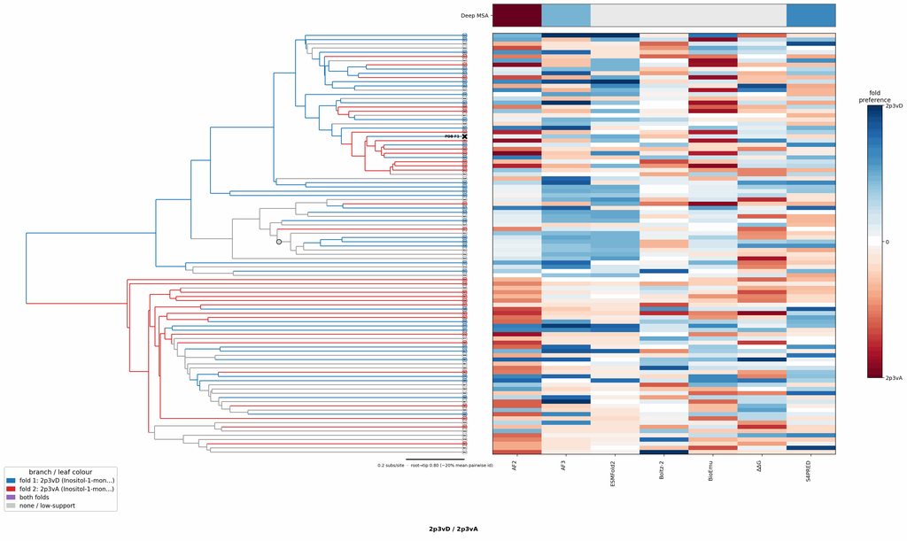

## Figure 2: Aligned overlay (both folds superposed)

The single fold-switching chain of each fold superposed by TM-align; waters hidden, any ligand shown as green sticks. Grey = structurally conserved core, colour = divergent (fold-switching) region.

2p3vD (Inositol-1-monophosphatase)2p3vA (Inositol-1-monophosphatase)Ligand SRT (bound to 2p3vD), Ligand SRT (bound to 2p3vA)

TM-score: 0.956 · Trigger class: equilibrium_or_unknown

Aligned overlay

## Figure 3: The two folds, side by side

Each fold is coloured by per-residue Cα deviation between the two superposed structures: grey ≈ conserved core, full colour = structurally divergent (fold-switching) region.

2p3vD (Inositol-1-monophosphatase)

2p3vA (Inositol-1-monophosphatase)

0 Å5≥10 Å

2p3vD (Inositol-1-monophosphatase)

2p3vA (Inositol-1-monophosphatase)

## Figure 4: Best-cluster predicted contact maps over the two true folds.

Predicted contact maps (MSA-Transformer) for the clusters best matching each fold, over the true contacts of fold 1 (upper triangle) and fold 2 (lower). Divergent contacts between clusters are the contact-level signature of fold-switching.

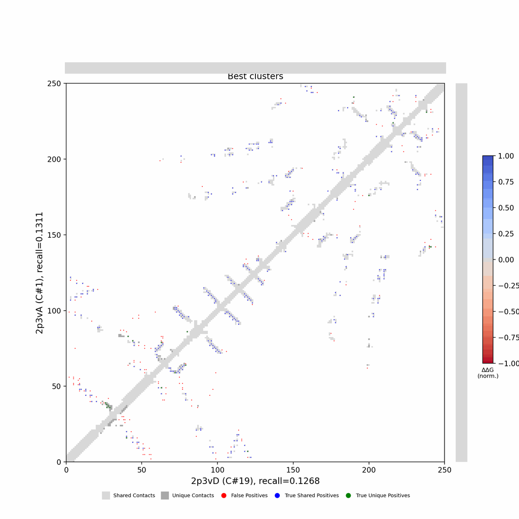

## Figure 5: Per-residue ΔΔG fold-preference contribution

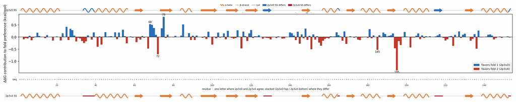

**More figures**

## Figure 6: Deep-MSA contact map panel / Best clusters contact map panel

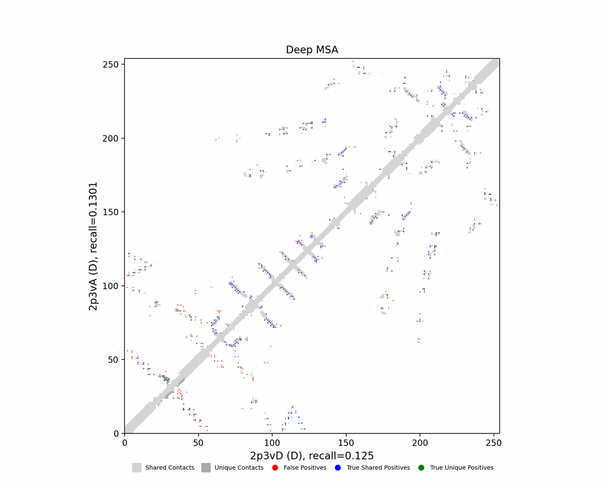

Deep-MSA contact map panel

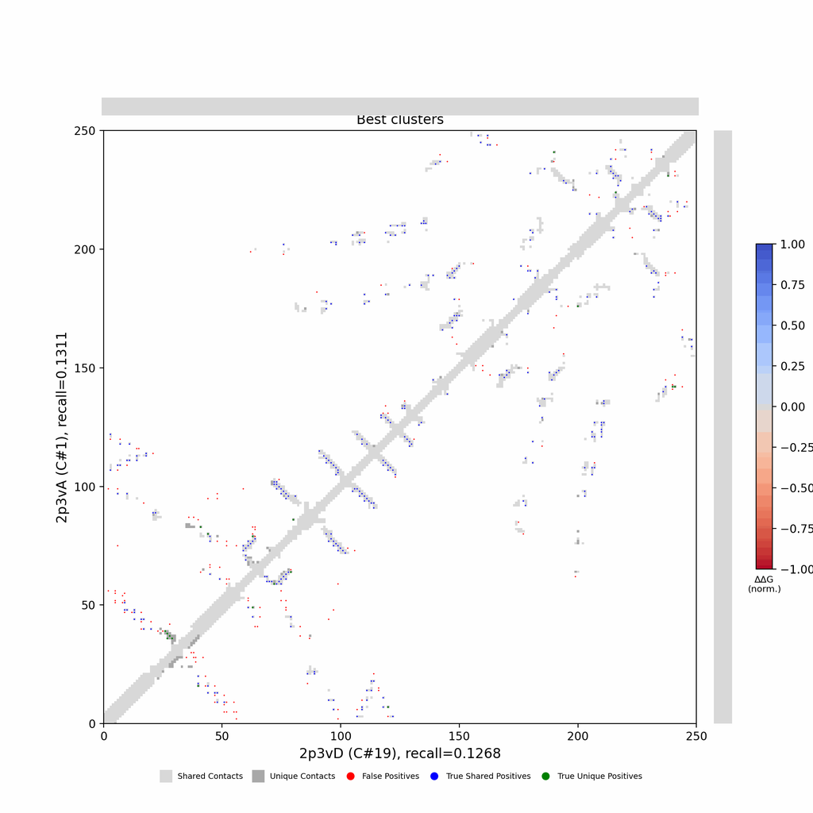

Best clusters contact map panel

## Figure 7: All clusters contact-map mosaic (small multiples).

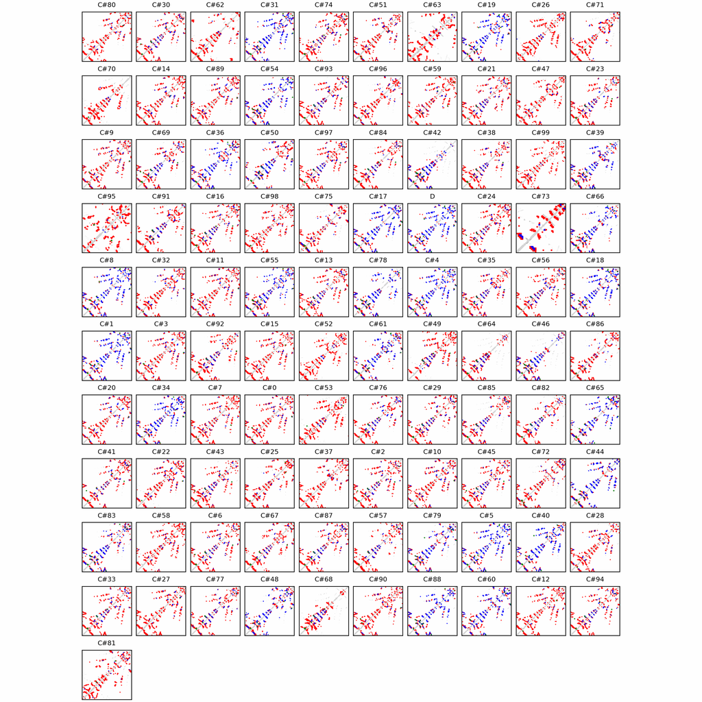

## Figure 8: Phylo null: tree with shuffled cluster fold labels.

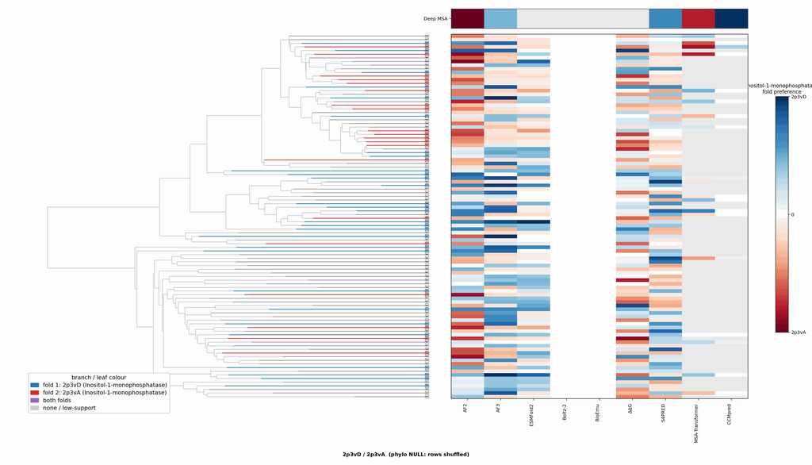

## Cluster metrics table

Per-cluster metrics underlying the figures above.

| cluster | n | neff | AF2_TM1 | AF2_TM2 | AF3_TM1 | AF3_TM2 | RE-MSAT-COM | RE-MSAT1 | RE-MSAT2 | ESM_SEQIDS | ESM_TM1 | ESM_TM2 | ΔΔG_Bias | ΔΔG_Bias_std | ΔΔG_frac_F1 | Boltz2_pref | S4PRED_pref | CCMpred_pref | BioEmu_pref |
| --- | --- | --- | --- | --- | --- | --- | --- | --- | --- | --- | --- | --- | --- | --- | --- | --- | --- | --- | --- |
| Deep | - | - | 0.94 | 0.98 | 0.96 | 0.94 | 0.48 | 0.48 | 0.5 | - | - | - | - | - | - | - | 0.03 | 0.0 | - |
| 000 | 666.0 | 619.0 | 0.88 | 0.9 | 0.88 | 0.91 | 0.1 | 0.1 | 0.1 | 001; 001; 003; 004; 008; 008; 004; 003; 007; 007 | 0.90 ± 0.04 | 0.87 ± 0.03 | -2.31 | 3.84 | 0.3 | -0.01 | -0.02 | 0.0 | -0.01 |
| 001 | 642.0 | 576.0 | 0.68 | 0.66 | 0.77 | 0.75 | 0.48 | 0.48 | 0.49 | 005; 005; 006; 006; 001; 002; 004; 002; 001; 004 | 0.89 ± 0.01 | 0.87 ± 0.01 | 0.01 | 2.92 | 0.2 | -0.0 | 0.0 | 0.0 | 0.01 |
| 002 | 529.0 | 493.0 | 0.86 | 0.85 | 0.84 | 0.86 | 0.12 | 0.12 | 0.14 | 001; 001; 005; 005; 006; 008; 008; 006; 004; 004 | 0.87 ± 0.02 | 0.86 ± 0.01 | -2.27 | 4.73 | 0.4 | -0.01 | -0.0 | 0.0 | 0.0 |
| 003 | 468.0 | 417.0 | 0.86 | 0.84 | 0.86 | 0.89 | 0.1 | 0.11 | 0.1 | 001; 001; 003; 003; 004; 004; 005; 005; 002; 006 | 0.88 ± 0.02 | 0.87 ± 0.02 | -2.33 | 3.48 | 0.4 | -0.0 | -0.03 | 0.0 | -0.01 |
| 004 | 431.0 | 407.0 | 0.87 | 0.88 | 0.89 | 0.92 | 0.47 | 0.47 | 0.48 | 001; 002; 002; 001; 006; 007; 006; 007; 005; 005 | 0.88 ± 0.01 | 0.86 ± 0.01 | -0.16 | 2.6 | 0.6 | -0.02 | 0.02 | 0.0 | 0.0 |
| 005 | 397.0 | 380.0 | 0.79 | 0.77 | 0.87 | 0.85 | 0.46 | 0.47 | 0.47 | 001; 004; 004; 001; 006; 006; 007; 007; 009; 009 | 0.91 ± 0.03 | 0.89 ± 0.01 | 0.48 | 4.4 | 0.5 | -0.01 | -0.01 | 0.0 | 0.01 |
| 006 | 388.0 | 376.0 | 0.89 | 0.88 | 0.88 | 0.91 | 0.12 | 0.13 | 0.14 | 001; 001; 002; 002; 006; 006; 007; 007; 003; 003 | 0.91 ± 0.03 | 0.89 ± 0.03 | -0.84 | 2.59 | 0.4 | 0.0 | -0.01 | 0.0 | -0.01 |
| 007 | 372.0 | 354.0 | 0.79 | 0.79 | 0.88 | 0.9 | 0.08 | 0.08 | 0.08 | 001; 001; 002; 002; 004; 004; 003; 003; 006; 006 | 0.86 ± 0.03 | 0.86 ± 0.02 | -0.47 | 3.2 | 0.6 | -0.0 | -0.03 | 0.0 | -0.0 |
| 008 | 294.0 | 280.0 | 0.86 | 0.88 | 0.89 | 0.92 | 0.46 | 0.46 | 0.47 | 002; 002; 001; 008; 008; 001; 005; 005; 007; 004 | 0.88 ± 0.01 | 0.86 ± 0.01 | -1.69 | 3.47 | 0.2 | -0.0 | -0.0 | 0.0 | -0.02 |
| 009 | 246.0 | 238.0 | 0.8 | 0.78 | 0.86 | 0.89 | 0.09 | 0.1 | 0.09 | 001; 001; 004; 008; 008; 004; 003; 003; 009; 009 | 0.86 ± 0.02 | 0.86 ± 0.02 | -0.71 | 2.48 | 0.4 | 0.01 | 0.0 | 0.0 | 0.0 |
| 010 | 216.0 | 206.0 | 0.42 | 0.42 | 0.5 | 0.5 | 0.1 | 0.1 | 0.1 | 001; 001; 005; 005; 004; 006; 006; 004; 007; 007 | 0.89 ± 0.01 | 0.87 ± 0.01 | -0.24 | 2.52 | 0.4 | -0.01 | -0.0 | 0.0 | -0.0 |
| 011 | 157.0 | 150.0 | 0.45 | 0.45 | 0.5 | 0.5 | 0.1 | 0.11 | 0.1 | 007; 007; 001; 006; 001; 006; 005; 005; 008; 008 | 0.90 ± 0.01 | 0.88 ± 0.01 | 0.05 | 2.21 | 0.5 | -0.0 | 0.0 | 0.0 | -0.0 |
| 012 | 155.0 | 147.0 | 0.78 | 0.78 | 0.84 | 0.85 | 0.04 | 0.04 | 0.04 | 001; 001; 004; 004; 005; 005; 003; 002; 003; 002 | 0.90 ± 0.01 | 0.88 ± 0.02 | -0.91 | 3.26 | 0.4 | 0.01 | 0.01 | 0.0 | -0.01 |
| 013 | 149.0 | 140.0 | 0.8 | 0.79 | 0.79 | 0.77 | 0.16 | 0.15 | 0.16 | 001; 008; 008; 001; 006; 006; 002; 002; 009; 009 | 0.91 ± 0.01 | 0.89 ± 0.01 | -1.7 | 3.28 | 0.5 | -0.02 | 0.0 | 0.0 | 0.0 |
| 014 | 138.0 | 132.0 | 0.5 | 0.52 | 0.52 | 0.55 | 0.08 | 0.09 | 0.09 | 001; 001; 006; 006; 002; 007; 007; 002; 008; 008 | 0.90 ± 0.02 | 0.89 ± 0.01 | -0.26 | 2.52 | 0.4 | -0.02 | -0.03 | 0.0 | -0.02 |
| 015 | 132.0 | 123.0 | 0.94 | 0.97 | 0.93 | 0.97 | 0.05 | 0.05 | 0.05 | 004; 004; 009; 009; 002; 002; 006; 006; 003; 005 | 0.84 ± 0.03 | 0.84 ± 0.03 | -1.6 | 3.0 | 0.4 | 0.0 | -0.03 | 0.0 | -0.02 |
| 016 | 132.0 | 130.0 | 0.8 | 0.78 | 0.47 | 0.44 | 0.14 | 0.14 | 0.16 | 001; 006; 006; 001; 007; 008; 007; 008; 002; 002 | 0.90 ± 0.02 | 0.88 ± 0.01 | -2.68 | 2.75 | 0.2 | -0.0 | -0.02 | 0.0 | 0.02 |
| 017 | 122.0 | 116.0 | 0.78 | 0.76 | 0.87 | 0.85 | 0.48 | 0.49 | 0.48 | 005; 005; 006; 006; 001; 004; 001; 004; 002; 002 | 0.91 ± 0.01 | 0.89 ± 0.02 | -0.22 | 1.4 | 0.5 | -0.0 | 0.02 | 0.0 | 0.01 |
| 018 | 122.0 | 117.0 | 0.91 | 0.94 | 0.94 | 0.97 | 0.48 | 0.49 | 0.49 | 004; 004; 001; 001; 005; 002; 002; 005; 007; 003 | 0.89 ± 0.02 | 0.86 ± 0.02 | 0.43 | 2.32 | 0.6 | -0.02 | -0.0 | 0.0 | -0.02 |
| 019 | 110.0 | 93.0 | 0.25 | 0.25 | 0.23 | 0.23 | 0.49 | 0.5 | 0.49 | - | - | - | -0.07 | 2.98 | 0.5 | -0.01 | -0.02 | - | 0.0 |
| 020 | 98.0 | 95.0 | 0.8 | 0.81 | 0.85 | 0.86 | 0.1 | 0.1 | 0.1 | - | - | - | 0.26 | 3.36 | 0.4 | -0.02 | -0.01 | - | -0.01 |
| 021 | 92.0 | 83.0 | 0.42 | 0.42 | 0.58 | 0.57 | 0.13 | 0.13 | 0.14 | - | - | - | -0.94 | 2.79 | 0.3 | 0.01 | -0.02 | - | -0.0 |
| 022 | 78.0 | 67.0 | 0.91 | 0.94 | 0.94 | 0.97 | 0.1 | 0.1 | 0.1 | - | - | - | -1.47 | 1.88 | 0.3 | 0.0 | -0.03 | - | -0.02 |
| 023 | 75.0 | 71.0 | 0.95 | 0.93 | 0.94 | 0.97 | 0.14 | 0.14 | 0.16 | - | - | - | 0.59 | 3.63 | 0.7 | 0.01 | 0.0 | - | -0.02 |
| 024 | 73.0 | 71.0 | 0.67 | 0.66 | 0.69 | 0.68 | 0.12 | 0.12 | 0.14 | - | - | - | -0.04 | 2.88 | 0.5 | 0.0 | -0.02 | - | 0.0 |
| 025 | 67.0 | 59.0 | 0.55 | 0.55 | 0.87 | 0.9 | 0.04 | 0.04 | 0.04 | - | - | - | 1.23 | 2.12 | 0.7 | 0.0 | -0.03 | - | -0.0 |
| 026 | 66.0 | 63.0 | 0.68 | 0.68 | 0.67 | 0.66 | 0.02 | 0.02 | 0.02 | - | - | - | -2.11 | 2.89 | 0.2 | 0.0 | -0.01 | - | -0.0 |
| 027 | 64.0 | 63.0 | 0.63 | 0.65 | 0.68 | 0.69 | 0.06 | 0.06 | 0.05 | - | - | - | -2.68 | 2.7 | 0.1 | -0.01 | -0.02 | - | -0.0 |
| 028 | 56.0 | 54.0 | 0.4 | 0.4 | 0.54 | 0.54 | 0.1 | 0.1 | 0.1 | - | - | - | 1.89 | 3.33 | 0.9 | -0.01 | 0.01 | - | 0.0 |

[output cut: 71 more lines]